# Assignment 2

DATA 311

Author

Noah Semashkewich

# Assignment 2

## **Exploratory / Pre-processing**

### Exercise 1)

The Telco Customer Churn prediction task is a **classification** and **supervised learning** problem.

- This is a **classification** problem because the goal is to predict whether a customer will churn (leave the service) or not, which is a binary outcome.
- This is a **supervised learning** problem because we are provided with labeled data (the target variable is whether the customer churned or not), so it is a supervised learning task.

### Exercise 2)

```r
telco_data = read.csv("Telco-Customer-Churn.csv")
str(telco_data)
```

```
'data.frame':   7043 obs. of  21 variables:
 $ customerID      : chr  "7590-VHVEG" "5575-GNVDE" "3668-QPYBK" "7795-CFOCW" ...
 $ gender          : chr  "Female" "Male" "Male" "Male" ...
 $ SeniorCitizen   : int  0 0 0 0 0 0 0 0 0 0 ...
 $ Partner         : chr  "Yes" "No" "No" "No" ...
 $ Dependents      : chr  "No" "No" "No" "No" ...
 $ tenure          : int  1 34 2 45 2 8 22 10 28 62 ...
 $ PhoneService    : chr  "No" "Yes" "Yes" "No" ...
 $ MultipleLines   : chr  "No phone service" "No" "No" "No phone service" ...
 $ InternetService : chr  "DSL" "DSL" "DSL" "DSL" ...
 $ OnlineSecurity  : chr  "No" "Yes" "Yes" "Yes" ...
 $ OnlineBackup    : chr  "Yes" "No" "Yes" "No" ...
 $ DeviceProtection: chr  "No" "Yes" "No" "Yes" ...
 $ TechSupport     : chr  "No" "No" "No" "Yes" ...
 $ StreamingTV     : chr  "No" "No" "No" "No" ...
 $ StreamingMovies : chr  "No" "No" "No" "No" ...
 $ Contract        : chr  "Month-to-month" "One year" "Month-to-month" "One year" ...
 $ PaperlessBilling: chr  "Yes" "No" "Yes" "No" ...
 $ PaymentMethod   : chr  "Electronic check" "Mailed check" "Mailed check" "Bank transfer (automatic)" ...
 $ MonthlyCharges  : num  29.9 57 53.9 42.3 70.7 ...
 $ TotalCharges    : num  29.9 1889.5 108.2 1840.8 151.7 ...
 $ Churn           : chr  "No" "No" "Yes" "No" ...
```

```r
telco_data$gender = as.factor(telco_data$gender)
telco_data$Partner = as.factor(telco_data$Partner)
telco_data$Dependents = as.factor(telco_data$Dependents)
telco_data$PhoneService = as.factor(telco_data$PhoneService)
telco_data$MultipleLines = as.factor(telco_data$MultipleLines)
telco_data$InternetService = as.factor(telco_data$InternetService)
telco_data$OnlineSecurity = as.factor(telco_data$OnlineSecurity)
telco_data$OnlineBackup = as.factor(telco_data$OnlineBackup)
telco_data$DeviceProtection = as.factor(telco_data$DeviceProtection)
telco_data$TechSupport = as.factor(telco_data$TechSupport)
telco_data$StreamingTV = as.factor(telco_data$StreamingTV)
telco_data$StreamingMovies = as.factor(telco_data$StreamingMovies)
telco_data$Contract = as.factor(telco_data$Contract)
telco_data$PaperlessBilling = as.factor(telco_data$PaperlessBilling)
telco_data$PaymentMethod = as.factor(telco_data$PaymentMethod)
telco_data$Churn = as.factor(telco_data$Churn)
telco_data$SeniorCitizen = as.numeric(telco_data$SeniorCitizen)
telco_data$TotalCharges = as.numeric(telco_data$TotalCharges)
telco_data = na.omit(telco_data)

str(telco_data)
```

```
'data.frame':   7032 obs. of  21 variables:
 $ customerID      : chr  "7590-VHVEG" "5575-GNVDE" "3668-QPYBK" "7795-CFOCW" ...
 $ gender          : Factor w/ 2 levels "Female","Male": 1 2 2 2 1 1 2 1 1 2 ...
 $ SeniorCitizen   : num  0 0 0 0 0 0 0 0 0 0 ...
 $ Partner         : Factor w/ 2 levels "No","Yes": 2 1 1 1 1 1 1 1 2 1 ...
 $ Dependents      : Factor w/ 2 levels "No","Yes": 1 1 1 1 1 1 2 1 1 2 ...
 $ tenure          : int  1 34 2 45 2 8 22 10 28 62 ...
 $ PhoneService    : Factor w/ 2 levels "No","Yes": 1 2 2 1 2 2 2 1 2 2 ...
 $ MultipleLines   : Factor w/ 3 levels "No","No phone service",..: 2 1 1 2 1 3 3 2 3 1 ...
 $ InternetService : Factor w/ 3 levels "DSL","Fiber optic",..: 1 1 1 1 2 2 2 1 2 1 ...
 $ OnlineSecurity  : Factor w/ 3 levels "No","No internet service",..: 1 3 3 3 1 1 1 3 1 3 ...
 $ OnlineBackup    : Factor w/ 3 levels "No","No internet service",..: 3 1 3 1 1 1 3 1 1 3 ...
 $ DeviceProtection: Factor w/ 3 levels "No","No internet service",..: 1 3 1 3 1 3 1 1 3 1 ...
 $ TechSupport     : Factor w/ 3 levels "No","No internet service",..: 1 1 1 3 1 1 1 1 3 1 ...
 $ StreamingTV     : Factor w/ 3 levels "No","No internet service",..: 1 1 1 1 1 3 3 1 3 1 ...
 $ StreamingMovies : Factor w/ 3 levels "No","No internet service",..: 1 1 1 1 1 3 1 1 3 1 ...
 $ Contract        : Factor w/ 3 levels "Month-to-month",..: 1 2 1 2 1 1 1 1 1 2 ...
 $ PaperlessBilling: Factor w/ 2 levels "No","Yes": 2 1 2 1 2 2 2 1 2 1 ...
 $ PaymentMethod   : Factor w/ 4 levels "Bank transfer (automatic)",..: 3 4 4 1 3 3 2 4 3 1 ...
 $ MonthlyCharges  : num  29.9 57 53.9 42.3 70.7 ...
 $ TotalCharges    : num  29.9 1889.5 108.2 1840.8 151.7 ...
 $ Churn           : Factor w/ 2 levels "No","Yes": 1 1 2 1 2 2 1 1 2 1 ...
 - attr(*, "na.action")= 'omit' Named int [1:11] 489 754 937 1083 1341 3332 3827 4381 5219 6671 ...
  ..- attr(*, "names")= chr [1:11] "489" "754" "937" "1083" ...
```

### Exercise 3)

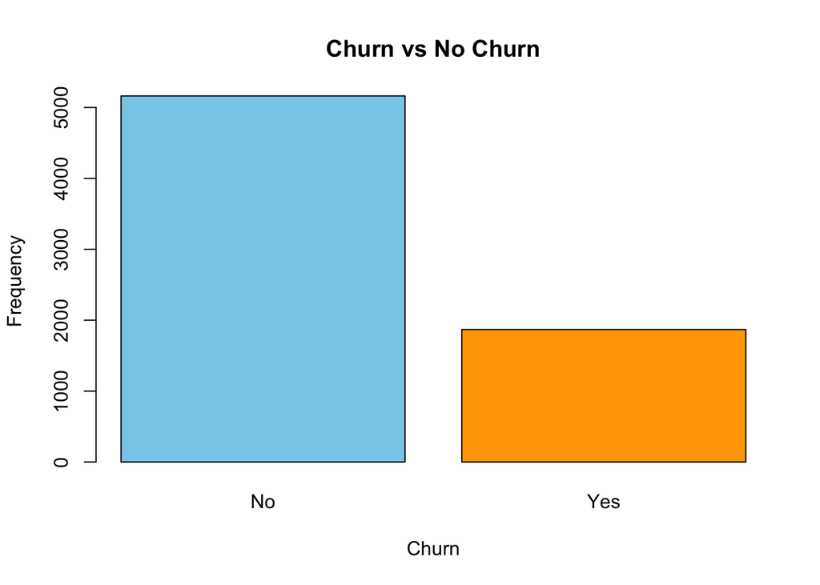

```r
churn_counts <- table(telco_data$Churn)
barplot(churn_counts,
        main = "Churn vs No Churn",
        xlab = "Churn",
        ylab = "Frequency",
        col = c("skyblue", "orange"))
```

```r
churn_counts
```

```
  No  Yes
5163 1869
```

The churn counts show that there are **5163 customers who did not churn (No)** and **1869 customers who churned (Yes)**. No churn (5163) is significantly higher then Yes churn (1869), which indicates that the data set is imbalanced.

What this implies for modeling:

- Model Bias Towards Majority Class: With most customers classified as “No”, the model may lean towards predicting the majority class more often, which can overlook the minority (churners).
- Poor Recall in Minority Class: Imbalance can lead to poor recall for the minority class (“Yes”), meaning the model may not correctly identify all the customers who are likely to churn.
- Misleading Accuracy: Model may have a misleading accuracy due to the imbalance. i.e. if the model predicts “No” churn for every case, it could still achieve ~73% accuracy just by predicting the majority class, failing to identify actual churners.

### Exercise 4)

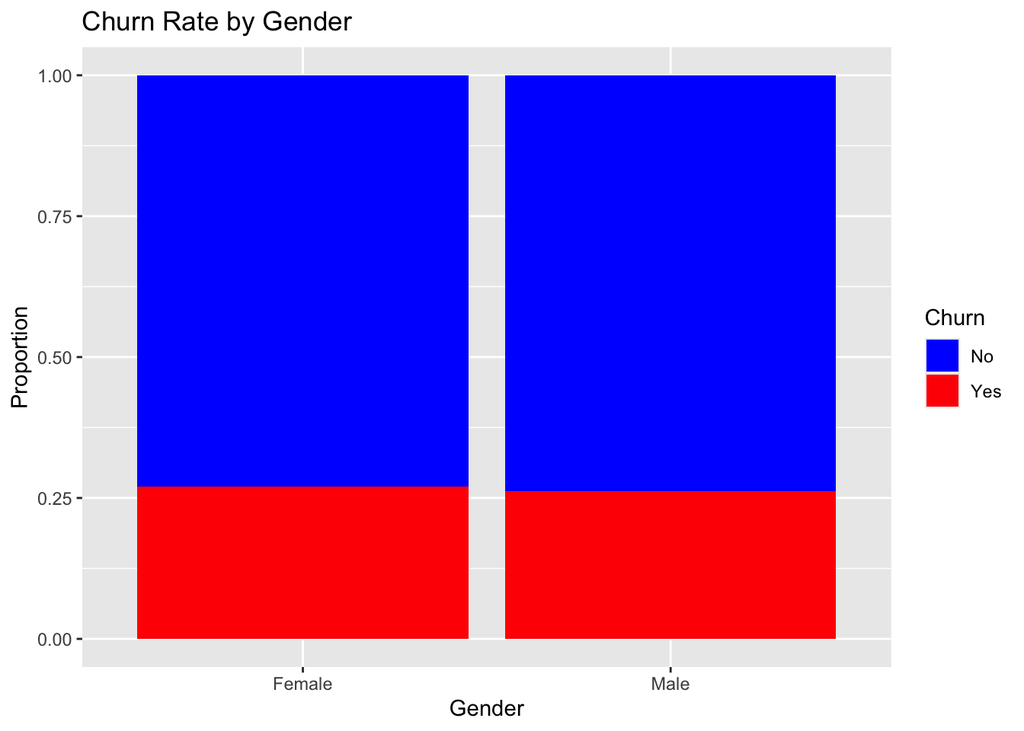

```r
library(ggplot2)
# Plotting Churn Rate by Gender
ggplot(telco_data, aes(x = gender, fill = Churn)) +
  geom_bar(position = "fill") +
  labs(title = "Churn Rate by Gender", y = "Proportion", x = "Gender") +
  scale_fill_manual(values = c("No" = "blue", "Yes" = "red"))
```

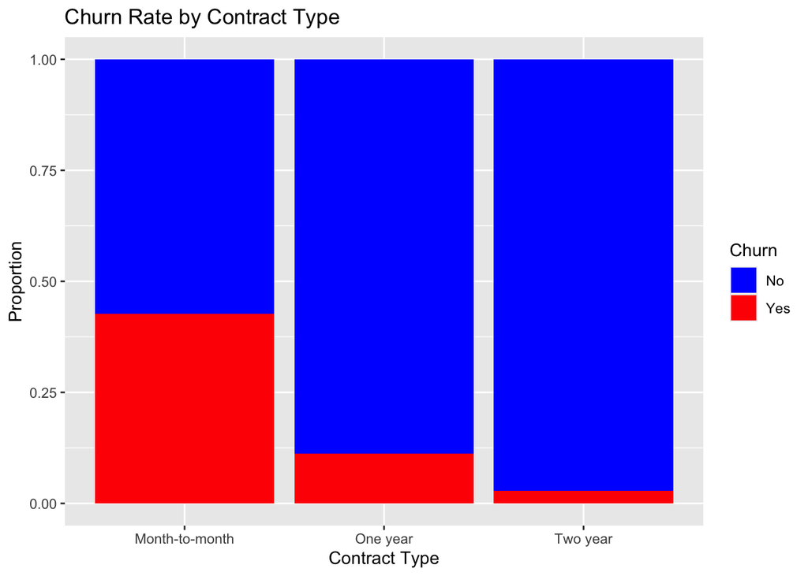

```r
# Plotting Churn Rate by Contract Type
ggplot(telco_data, aes(x = Contract, fill = Churn)) +
  geom_bar(position = "fill") +
  labs(title = "Churn Rate by Contract Type", y = "Proportion", x = "Contract Type") +
  scale_fill_manual(values = c("No" = "blue", "Yes" = "red"))
```

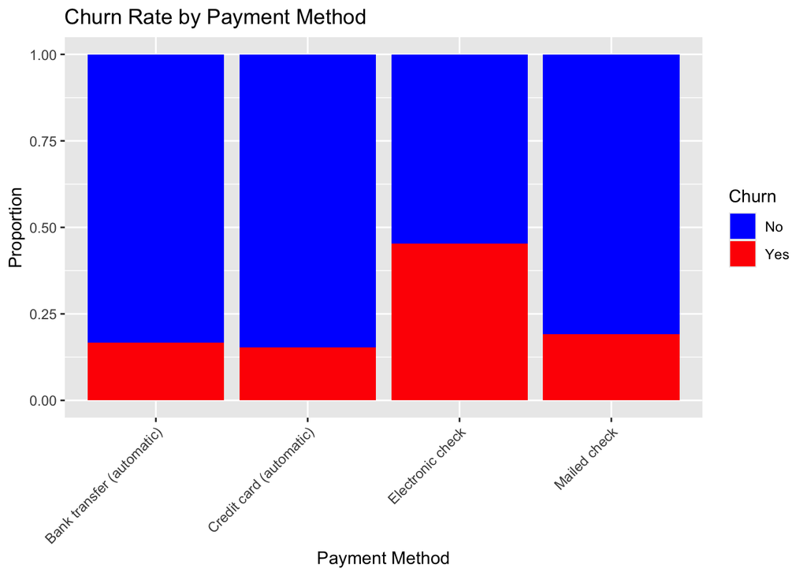

```r
# Bar plot for churn rate by Payment Method
ggplot(telco_data, aes(x = PaymentMethod, fill = Churn)) +
  geom_bar(position = "fill") +
  labs(title = "Churn Rate by Payment Method", y = "Proportion", x = "Payment Method") +
  scale_fill_manual(values = c("No" = "blue", "Yes" = "red")) +
  theme(axis.text.x = element_text(angle = 45, hjust = 1))  # Adjust the angle for better readability
```

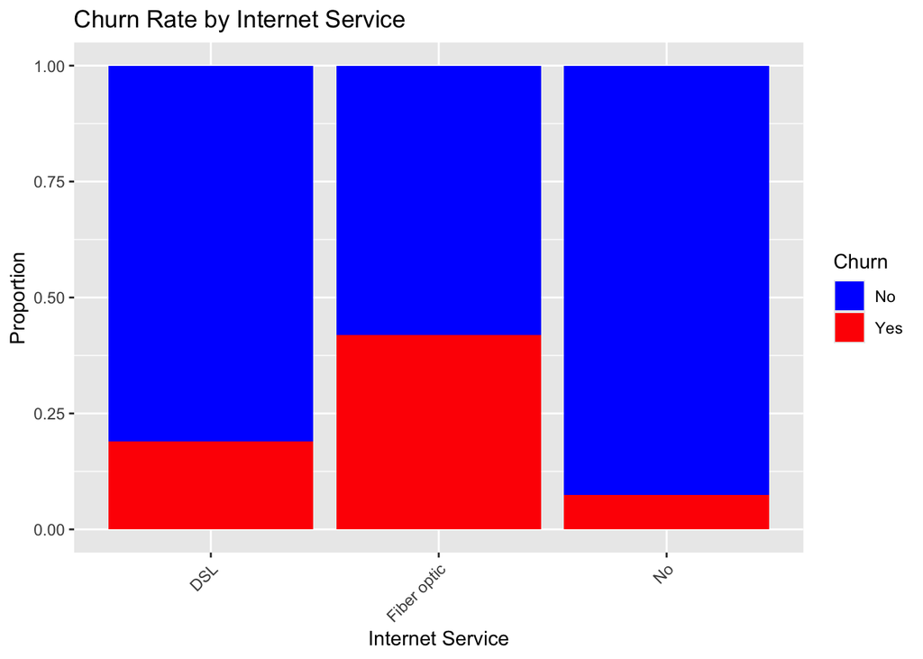

```r
# Bar plot for churn rate by Internet Service
ggplot(telco_data, aes(x = InternetService, fill = Churn)) +
  geom_bar(position = "fill") +
  labs(title = "Churn Rate by Internet Service", y = "Proportion", x = "Internet Service") +
  scale_fill_manual(values = c("No" = "blue", "Yes" = "red")) +
  theme(axis.text.x = element_text(angle = 45, hjust = 1))  # Adjust the angle for better readability
```